# EDA Final

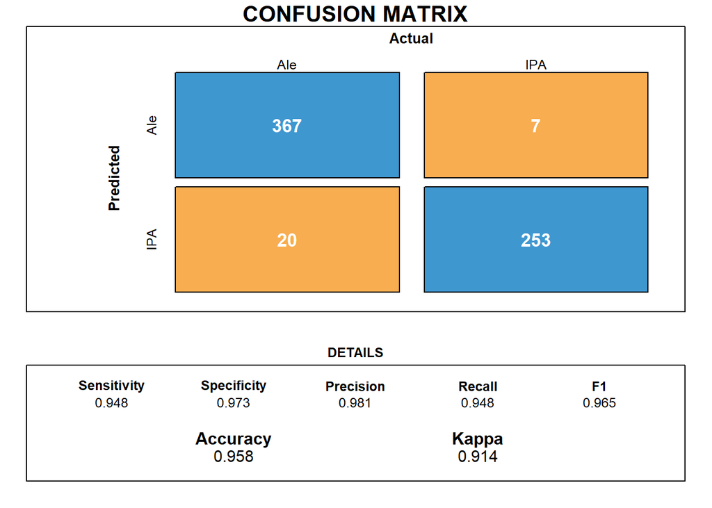

#KNN - This model omits NA values then scales ABV/IBU parameters to reduce leverage of nearest neighbor distances due to differing scales. Then it loops to find average confusion matrix parameters over iterations and plots for optimal k value. See comments after plots where single confusion matrix created using optimal k

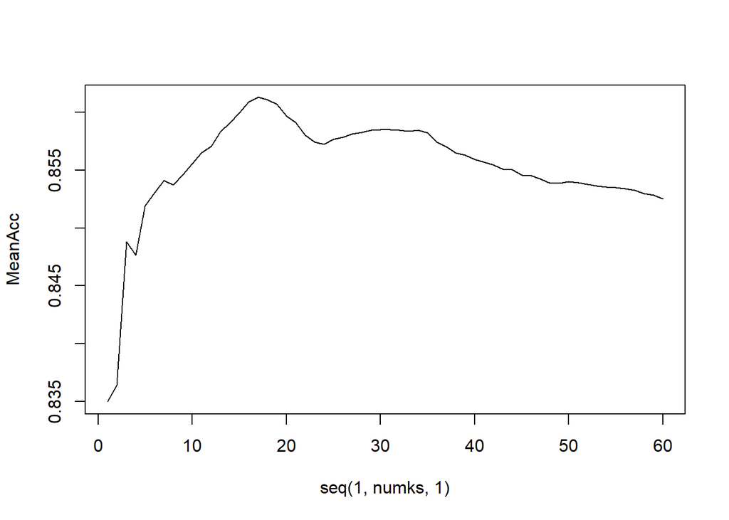

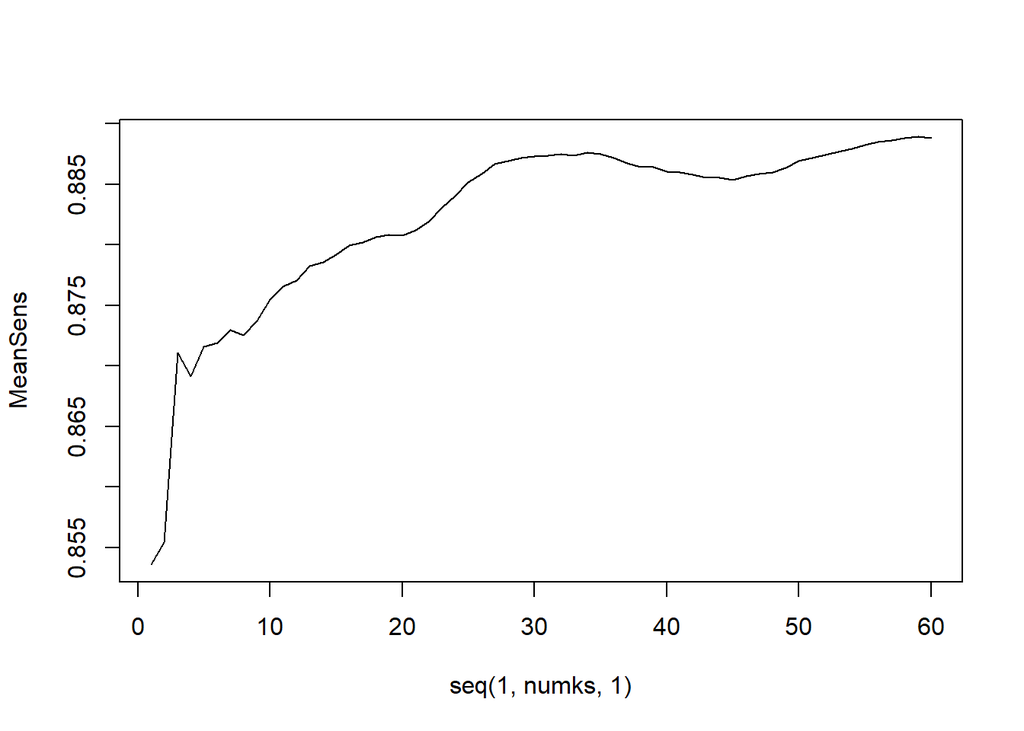

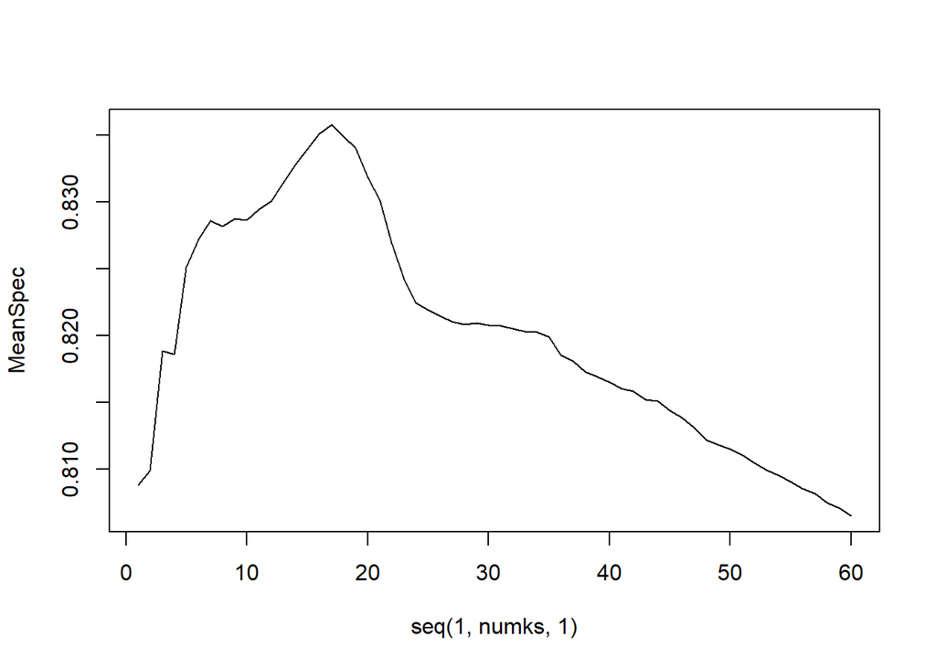

```
##      classifications
##       Ale IPA
##   Ale 137  23
##   IPA  12 113
```

```
## Confusion Matrix and Statistics
##
##      classifications
##       Ale IPA
##   Ale 137  23
##   IPA  12 113
##
##                Accuracy : 0.8772
##                  95% CI : (0.8334, 0.9129)
##     No Information Rate : 0.5228
##     P-Value [Acc > NIR] : < 2e-16
##
##                   Kappa : 0.753
##
##  Mcnemar's Test P-Value : 0.09097
##
##             Sensitivity : 0.9195
##             Specificity : 0.8309
##          Pos Pred Value : 0.8562
##          Neg Pred Value : 0.9040
##              Prevalence : 0.5228
##          Detection Rate : 0.4807
##    Detection Prevalence : 0.5614
##       Balanced Accuracy : 0.8752
##
##        'Positive' Class : Ale
##
```

#KNN - Unlike above models where NA values were omitted, this model uses the imputed IBU and ABV values using the Redictive Mean Matching (PMM) discussed in sections above.

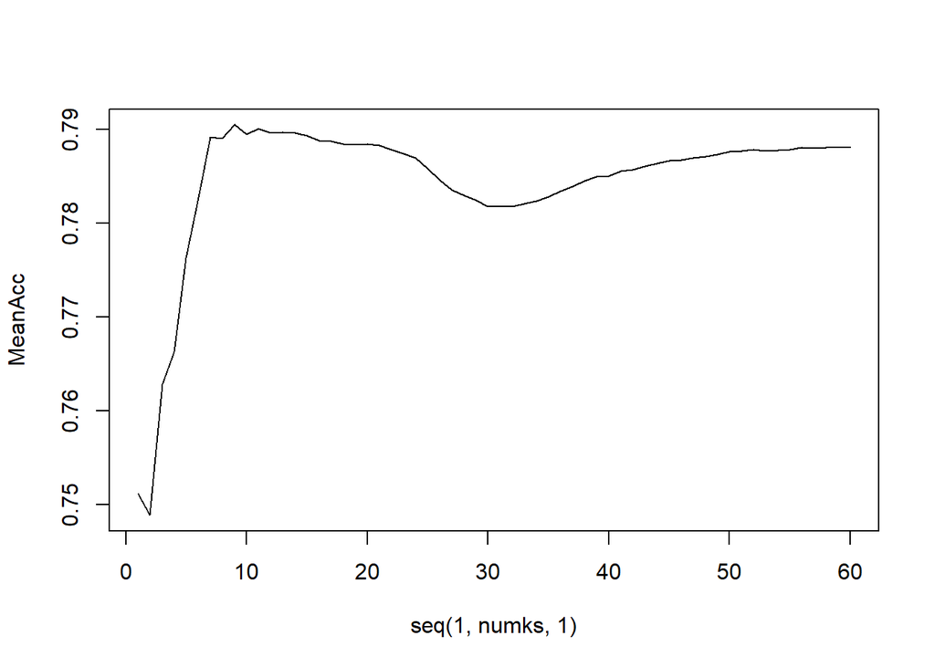

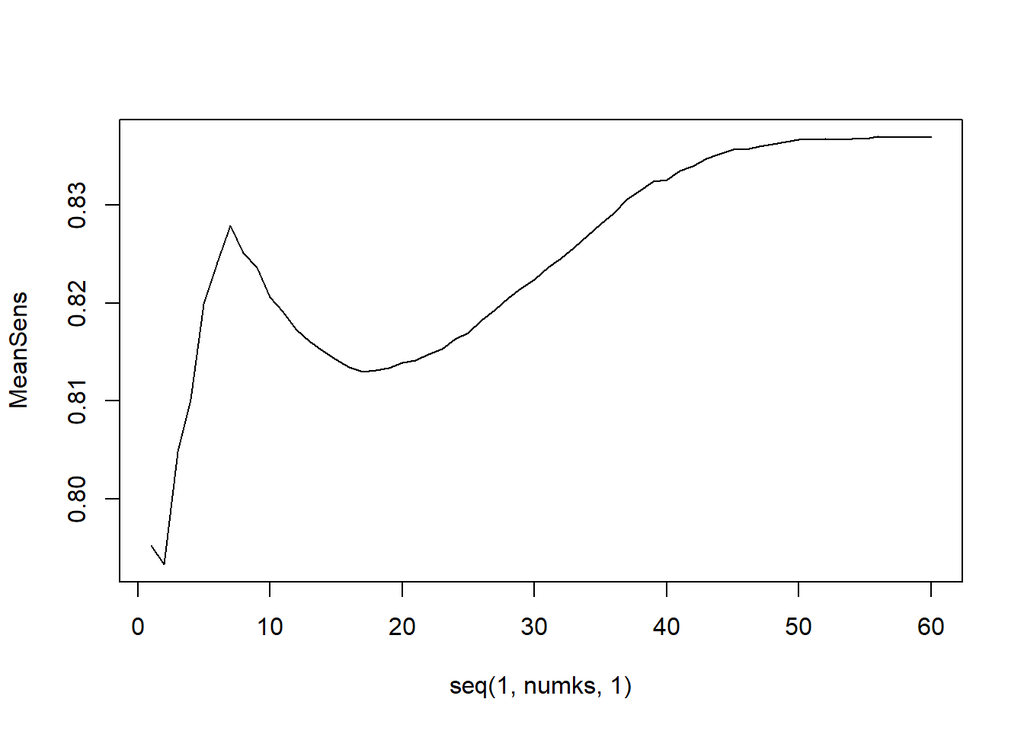

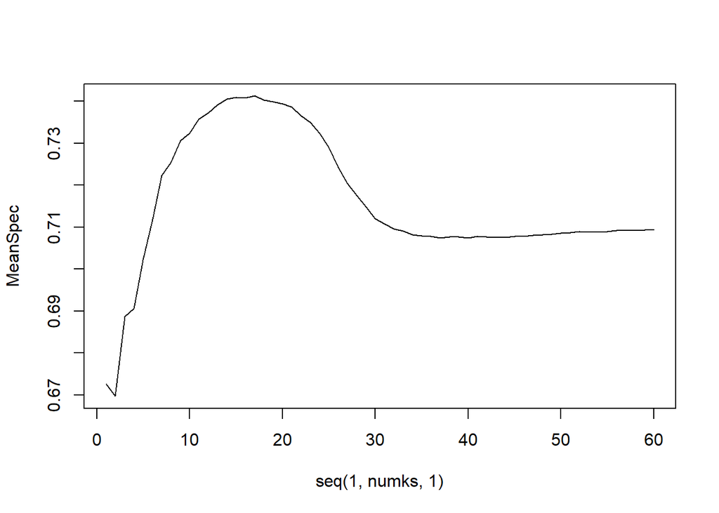

#KNN - PMM - Scale ABV/IBU

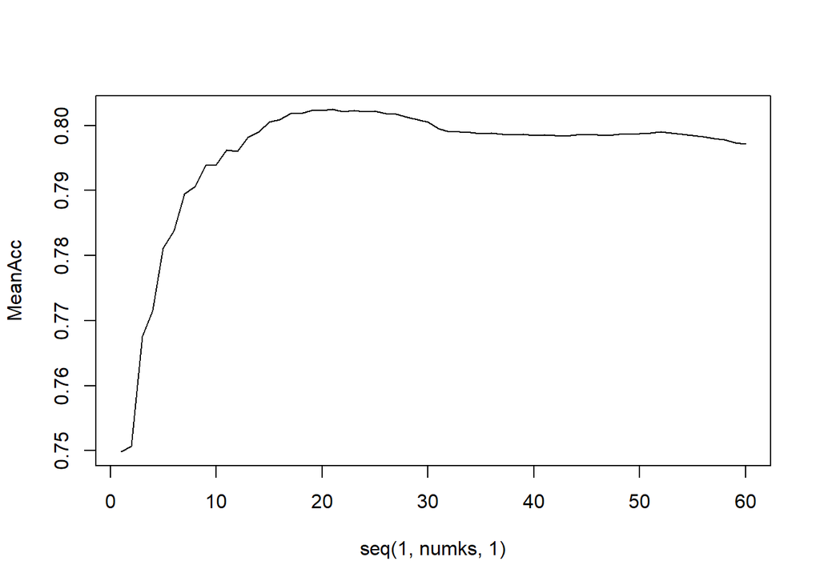

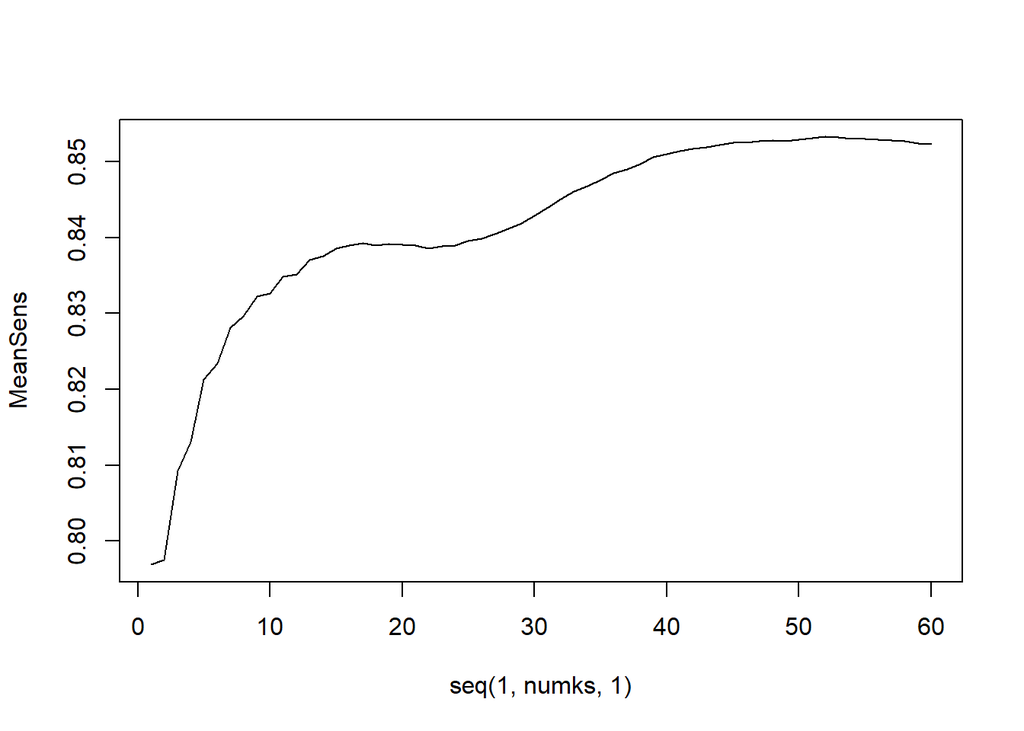

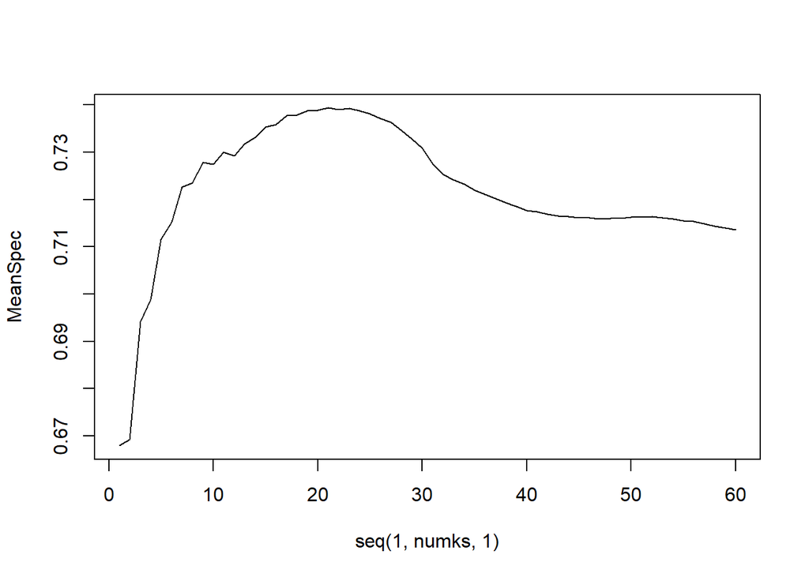

#KNN - CLASS

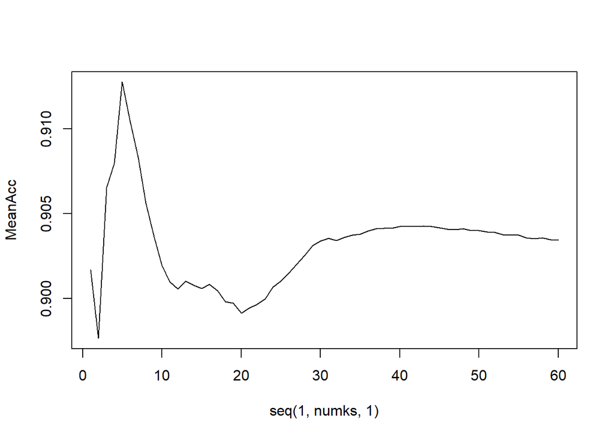

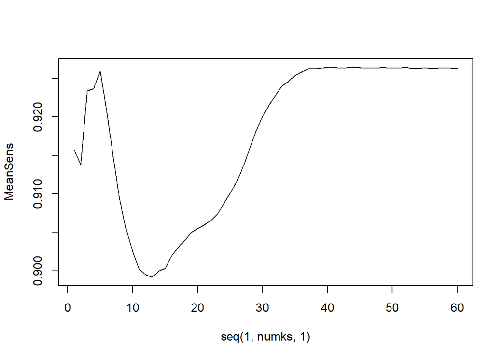

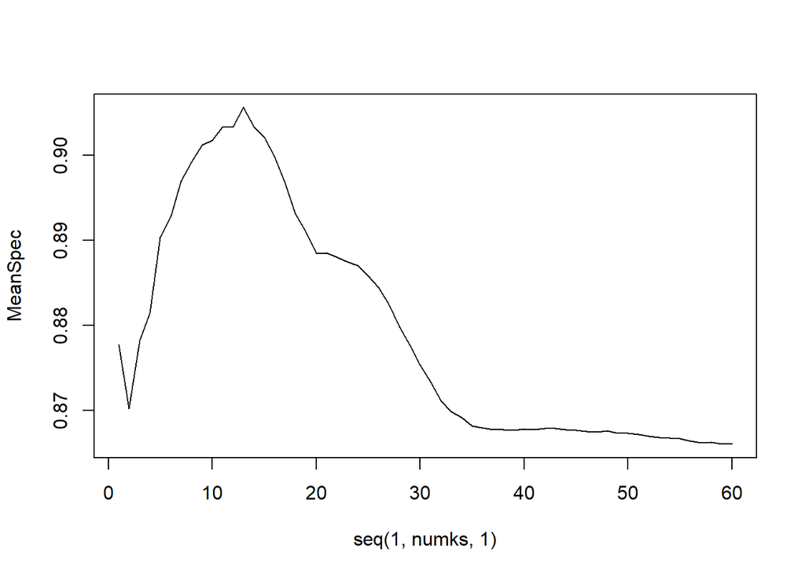

#KNN - CLASS - Scale ABV/IBU

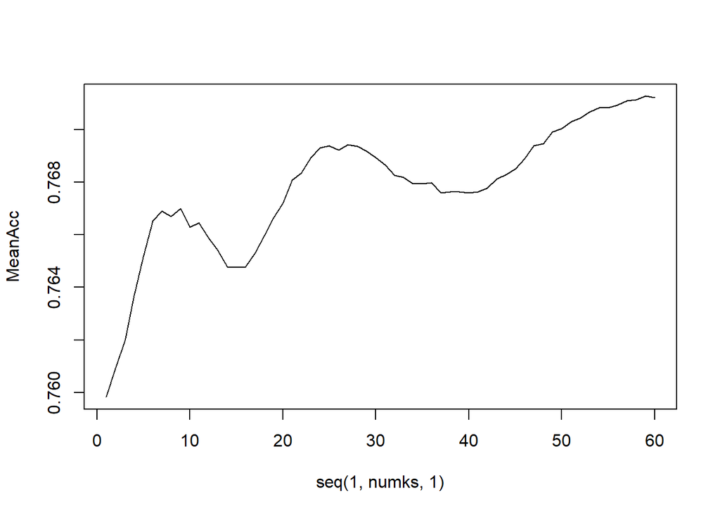

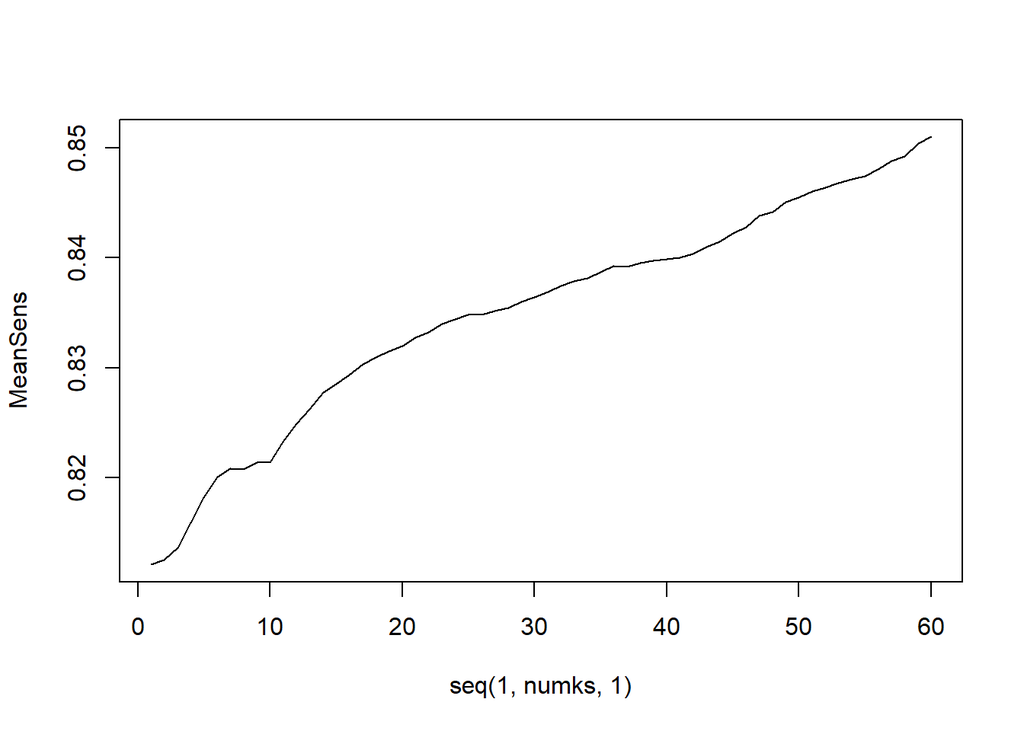

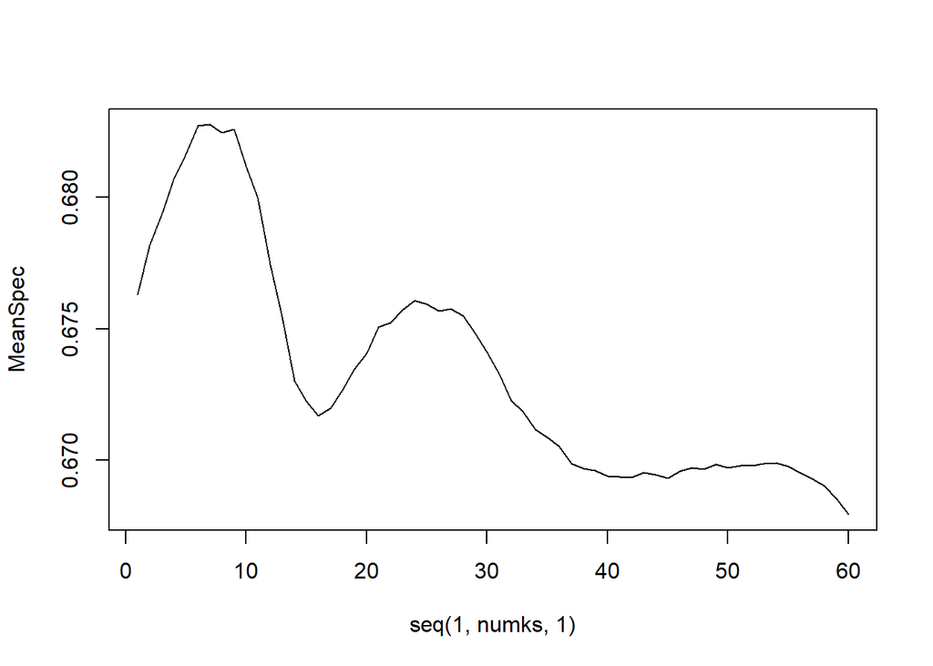

Our best model can classify Ales vs. IPA with 95% accuracy using their IBU and ABV measurements alone. If overfitting is a concern, higher values of k still produce accuracy of 85% which is still a good model.

Question 9: Knock their socks off! Find one other useful inference from the data that you feel Budweiser may be able to find value in. You must convince them why it is important and back up your conviction with appropriate statistical evidence.

We will analyze alcohol consumption data as a proxy for demand and consumer interest in beer vs. the location of existing breweries to look for opportunities of high demand with lower supply.

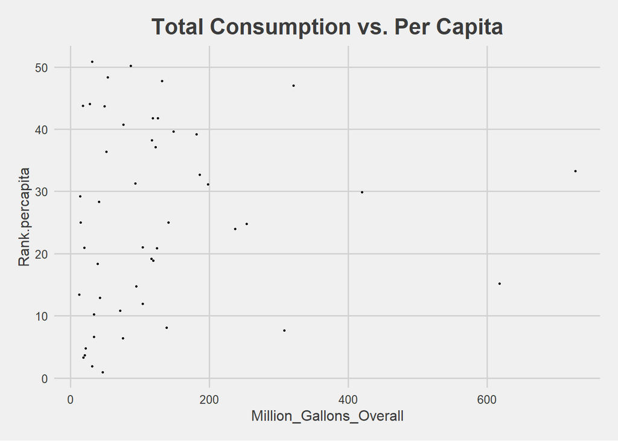

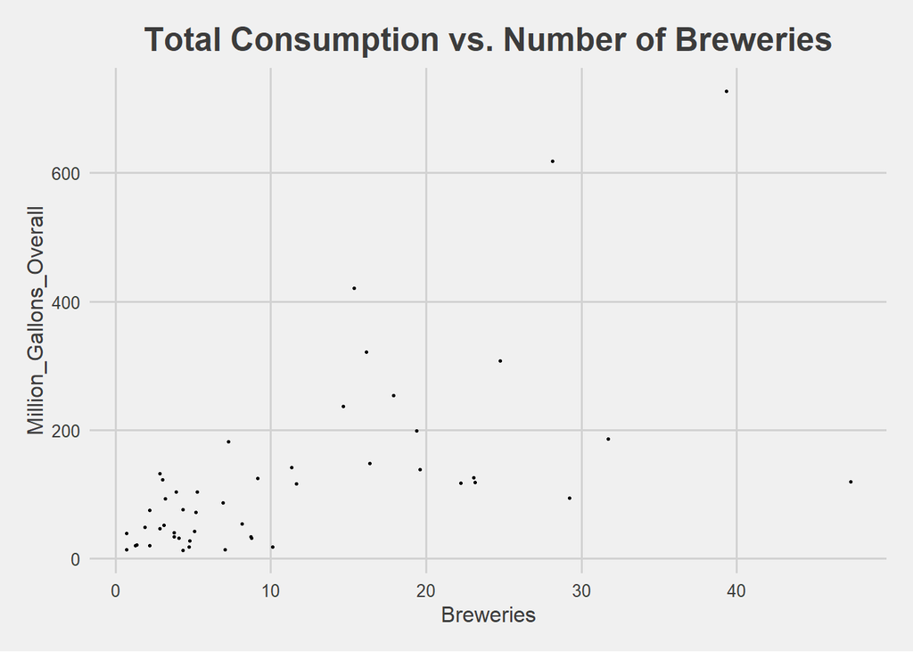

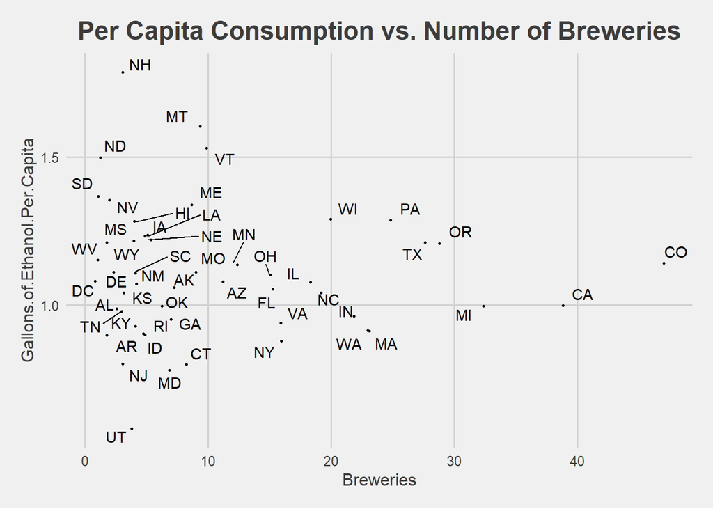

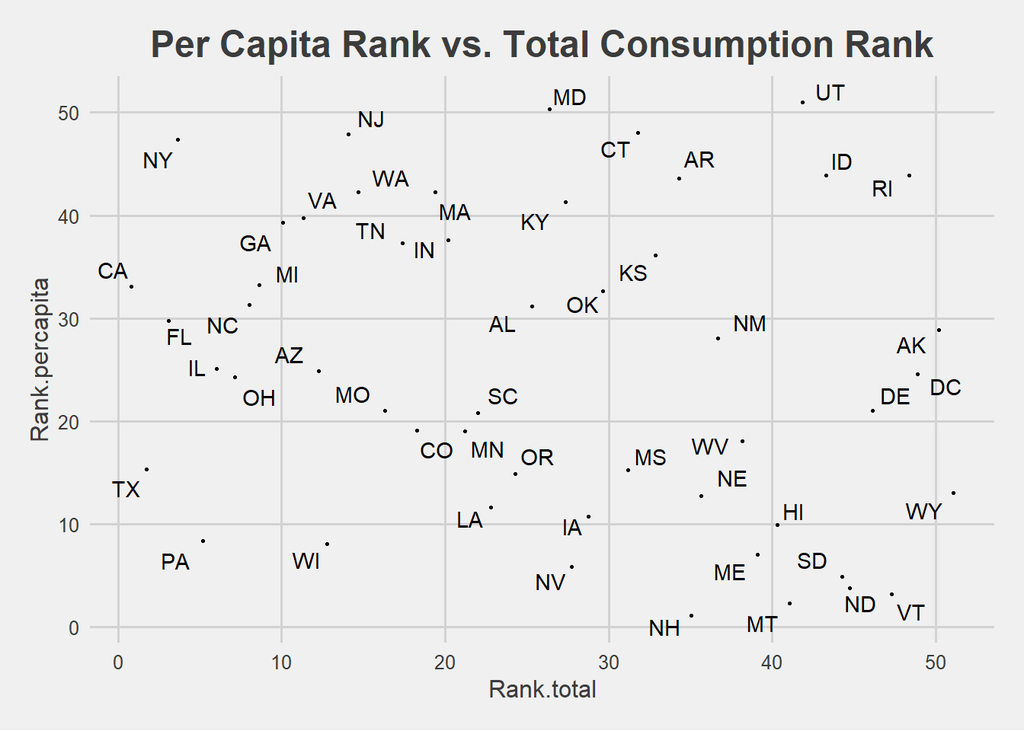

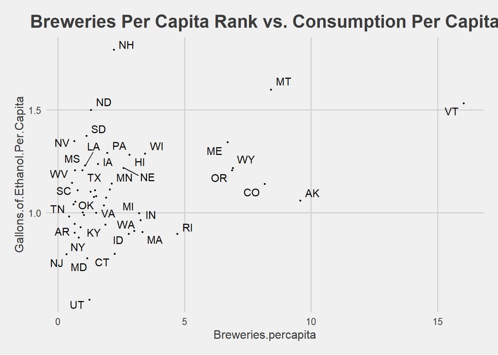

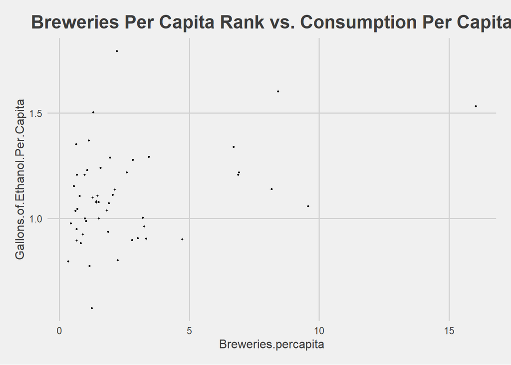

```
##             city      lat        lon
## 1  baldwinsville 43.15870  -76.33270
## 2   cartersville 34.16510  -84.79994
## 3   cartersville 34.16510  -84.79994
## 4       columbus 39.96118  -82.99879
## 5     losangeles 34.05223 -118.24368
## 6         newark 40.73566  -74.17237
## 7   williamsburg 37.27070  -76.70746
## 8      fairfield 38.24936 -122.03997
## 9    fortcollins 40.58526 -105.08442
## 10       houston 29.76328  -95.36327
## 11  jacksonville 30.33218  -81.65565
## 12     merrimack 42.86509  -71.49340
## 13       stlouis 38.62727  -90.19789
```

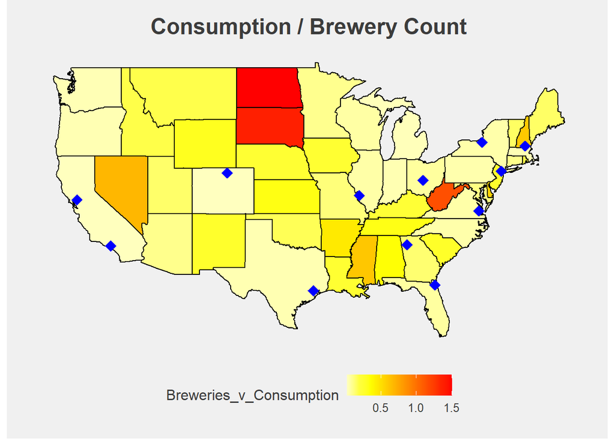

Answer 9: Some states with the highest alcohol consumption rate have very few breweries. There may be an opportunity to launch new beer with a brewery in these areas to create regional pride and increase demand for a new budweiser beer in a ripe market

Preliminary Analysis shows some states such as Nevada, South Dakota and North Dakota warrant further investigation in order to expand Budweiser’s share of craft brew market. These states demonstrate potential to support Budweiser Brewery Experiential Site

We’d recommend adding beer sales data provided by Budweiser so we can refine market analysis with more precise data. We would also like to include consumer taste preference for Beer with respect to IBU / ABV.